# BigMac

Jaime Duran

March 25, 2020

## Introduction

Get an estimated demand curve for Big Macs. Try to get elasticity demand

```r
BigMacdata = read.csv('Big Mac Price and Purchases.csv')
attach(BigMacdata)
```

plot the data

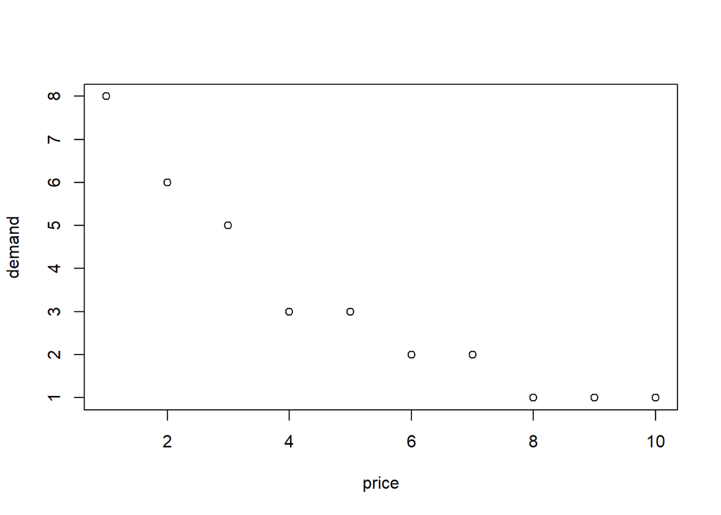

```r
plot(demand~price)
```

fit demand line to these data

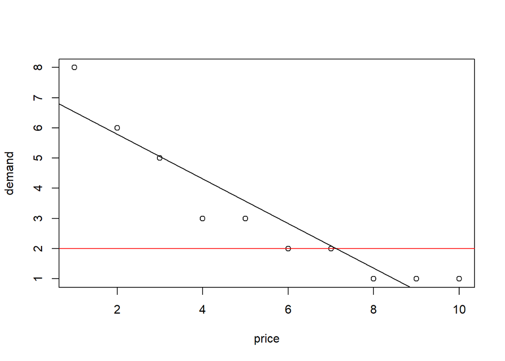

```r
priceOne = 4.00
model1 = lm(demand~price)
#summary(model1)
plot(demand~price)
abline(h = 2, col= "red")
abline(model1)
```

price elasticity is the % change in quantity demanded divided by the % change in price

marginal revenue is the additional revenue earned by selling one more unit of that product

MR = price * (1+elasticity)/elasticity

Elasticity = E

E = slope of demand at price P * (price/quantity)

```r
slope = model1$coefficients[2]
intercept = model1$coefficients[1]
demanded = (priceOne-intercept)/slope

E = slope*priceOne/demanded

MR = priceOne * abs((1+E)/E)
print(paste('elasticity = ', round(E,2)))
```

```
## [1] "elasticity =  -0.67"
```

```r
print(paste('MR = ', round(MR,2)))
```

```
## [1] "MR =  1.98"
```

Profit = price - cost = 4.0 - MC

```r
profit = priceOne - MR
print(paste('profit = ', profit))
```

```
## [1] "profit =  2.0247917226552"
```